# Synthetic mHealth Analysis with M²FPCA

A step-by-step walk-through: data exploration to digital biomarkers

M2FPCA package

2026-07-02

# 1 Introduction

This document reproduces, **step by step and on fully synthetic data**, the mobile-health (mHealth) analysis of Dey, Ghosal, Merikangas & Zipunnikov (2026), *Multivariate Functional Principal Component Analysis for Mixed-Type mHealth Data: An Application to Mood Disorders* ([arXiv:2603.11385](https://arxiv.org/abs/2603.11385)). **No real participant data from the NIMH Family Study is used or shown here** — everything below is generated from a known statistical model so that we can check the method against ground truth.

The scientific setup mirrors the paper: each participant-day is summarised by **four functional domains** measured through the waking day,

| Domain | Type | Source |
| --- | --- | --- |
| Sad Mood | ordinal | EMA (self-report) |
| Anxiousness | ordinal | EMA (self-report) |
| Energy | ordinal | EMA (self-report) |
| Total Log Activity (TLAC) | continuous | wrist actigraphy |

with four **diagnostic groups** (Control, MDD, Bipolar I, Bipolar II). The EMA domains are observed at only a handful of irregular times per day, while the actigraphy is dense — exactly the *asynchronous mixed-type* regime M²FPCA is built for.

The workflow is: **(1)** generate the data, **(2)** explore it, then run M²FPCA to **(3)** estimate the joint covariance, **(4)** extract shared principal components, **(5)** compute subject-level scores as digital biomarkers, and **(6)** predict diagnostic group from those scores.

# 2 Generate the synthetic data

The generator builds a *partially separable* latent process: all four domains share a common set of temporal eigenfunctions (a diurnal *level*, a morning–evening *contrast*, and a *circadian* mode), with cross-domain coupling entering through the component-score covariances. Group-specific shifts in a few score components make the diagnostic groups separable — these are the signal the method should recover. The latent curves are then mapped to their observed scales (ordinal Likert / continuous actigraphy) and thinned to mimic sparse EMA.

```r
sd_file <- file.path(cache, "synthetic_data.rds")
if (!file.exists(sd_file)) {
  # 01_generate_synthetic_data.R writes synthetic_data.rds into `cache`
  Sys.setenv(SDA_OUT = cache)
  invisible(capture.output(source("01_generate_synthetic_data.R")))
}
st <- readRDS(sd_file)
dat_list <- st$dat_list; type <- st$type; argvals <- st$argvals
hours <- st$hours; m <- st$m; p <- st$p; n <- st$n
domains <- st$domains; groups <- st$groups; group <- st$group

data.frame(domain = domains, type = type,
           row.names = names(dat_list))
```

```
##                  domain type
## SadMood        Sad Mood  ord
## Anx         Anxiousness  ord
## Energy           Energy  ord
## TLAC    TLAC (activity) cont
```

We have 160 synthetic subject-days on a common grid of 12 intra-day bins (07:00–22:00), across 4 domains and 4 diagnostic groups.

# 3 Data exploration

Before any modelling, we look at the raw data: how much is observed, what the distributions look like, and whether there is any visible cross-domain structure.

## 3.1 Missingness: sparse EMA vs. dense actigraphy

```r
obs_frac <- sapply(dat_list, function(X) mean(!is.na(X)))
obs_per_row <- sapply(dat_list, function(X) round(mean(rowSums(!is.na(X))), 1))
data.frame(`observed fraction` = round(obs_frac, 2),
           `avg observed bins/day` = obs_per_row,
           check.names = FALSE)
```

```
##         observed fraction avg observed bins/day
## SadMood              0.60                   7.2
## Anx                  0.61                   7.3
## Energy               0.61                   7.3
## TLAC                 0.96                  11.5
```

The three EMA domains are observed at ~60% of bins (about 7 of 12 per day), scattered irregularly, whereas actigraphy covers essentially the whole day. This asynchronous pattern is why a pairwise, co-observation–based estimator is needed.

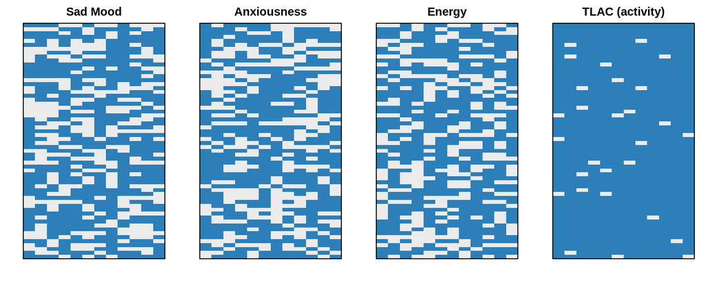

```r
op <- par(mfrow = c(1, 4), mar = c(2, 2, 2, 1))
for (v in 1:p) {
  image(1:m, 1:min(n, 60), t(!is.na(dat_list[[v]])[1:min(n,60), ]),
        col = c("grey92", "#2C7FB8"), axes = FALSE, main = domains[v],
        xlab = "", ylab = "")
  box()
}
```

```r
par(op)
```

*Blue = observed, grey = missing, for the first 60 subject-days. The EMA panels are sparse and asynchronous; TLAC is nearly complete.*

## 3.2 Ordinal category distributions

```r
cat_tab <- sapply(dat_list[1:3], function(X)
  round(prop.table(table(factor(X, levels = 0:2))), 2))
rownames(cat_tab) <- paste("level", 0:2)
cat_tab
```

```
##         SadMood  Anx Energy
## level 0    0.33 0.33   0.31
## level 1    0.34 0.32   0.35
## level 2    0.33 0.34   0.34
```

Each EMA domain uses three ordinal levels with reasonable spread — no empty or degenerate categories, which the copula margins require.

## 3.3 Example diurnal trajectories

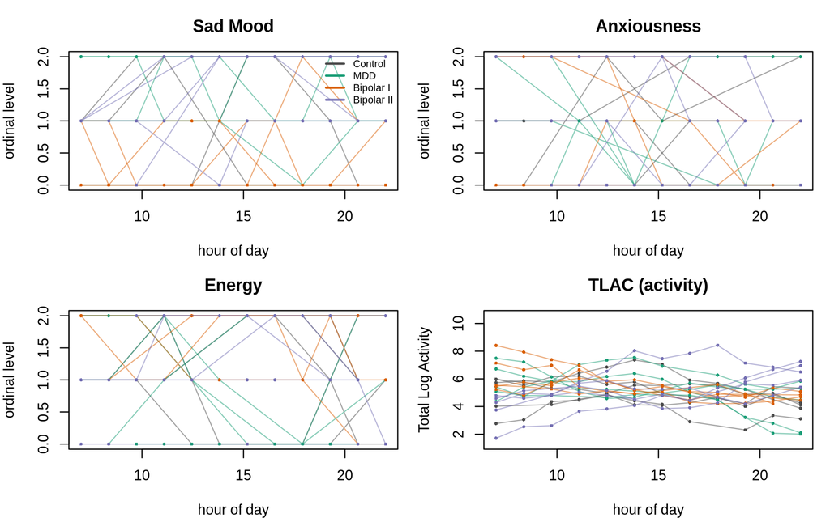

```r
gcol <- c(Control = "#4D4D4D", MDD = "#1B9E77",
          `Bipolar I` = "#D95F02", `Bipolar II` = "#7570B3")
set.seed(3)
op <- par(mfrow = c(2, 2), mar = c(4, 4, 3, 1))
for (v in 1:p) {
  X <- dat_list[[v]]
  yl <- if (v == 4) "Total Log Activity" else "ordinal level"
  plot(NA, xlim = range(hours), ylim = range(X, na.rm = TRUE),
       xlab = "hour of day", ylab = yl, main = domains[v])
  for (g in seq_along(groups)) {
    idx <- sample(which(group == groups[g]), 5)
    for (i in idx) {
      xi <- X[i, ]; ok <- !is.na(xi)
      lines(hours[ok], xi[ok], col = adjustcolor(gcol[g], .5))
      points(hours[ok], xi[ok], col = gcol[g], pch = 16, cex = .5)
    }
  }
  if (v == 1) legend("topright", names(gcol), col = gcol, lwd = 2,
                     cex = .7, bty = "n")
}
```

```r
par(op)
```

Individual curves are noisy and irregularly sampled — the diurnal structure and group differences are not obvious by eye. That is the motivation for pooling information across subjects with M²FPCA.

## 3.4 A first look at cross-domain association

A quick, model-free check: the day-level average of each domain per subject, and their correlations. (This ignores the functional/temporal structure but hints at coupling.)

```r
day_means <- sapply(dat_list, function(X) rowMeans(X, na.rm = TRUE))
round(cor(day_means, use = "pairwise.complete.obs"), 2)
```

```
##         SadMood   Anx Energy  TLAC
## SadMood    1.00  0.45   0.19 -0.30
## Anx        0.45  1.00   0.14 -0.34
## Energy     0.19  0.14   1.00  0.32
## TLAC      -0.30 -0.34   0.32  1.00
```

Mood, anxiousness and energy are positively associated; activity relates negatively to the low-mood domains. M²FPCA will formalise this as *time-resolved* latent correlation surfaces.

# 4 Step 1 — Fit M²FPCA

```r
fit_file <- file.path(cache, "mpf.rds")
if (file.exists(fit_file)) {
  fit <- readRDS(fit_file)
} else {
  fit <- mpfpca.dir(dat_list, type = type, argvals = argvals,
                    df = 5, weights = TRUE, min_no_pairs = 15)
  saveRDS(fit, fit_file)
}
cat("shared components retained (L):", fit$L, "\n")
```

```
## shared components retained (L): 9
```

# 5 Step 2 — Shared eigenfunctions and variance explained

Under partial separability all domains share the eigenbasis `phi`. The leading modes are interpretable as *diurnal level*, *morning–evening contrast*, and a *circadian* return, as reported in the paper.

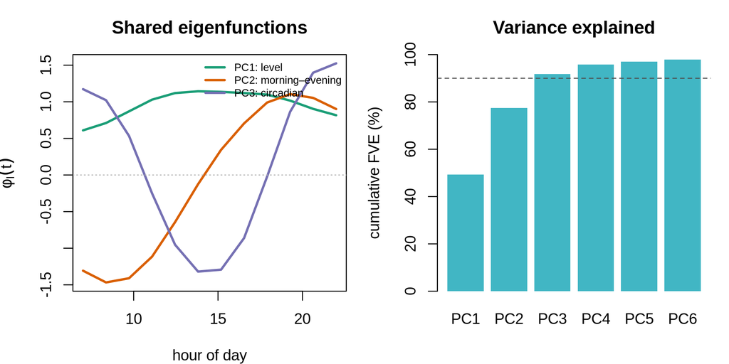

```r
phi_hat <- fit$pfpca_results[[1]]$phi
fve     <- fit$pfpca_results[[1]]$cumFVE
K <- min(3, ncol(phi_hat)); ecol <- c("#1B9E77", "#D95F02", "#7570B3")
op <- par(mfrow = c(1, 2), mar = c(4, 4, 3, 1))
matplot(hours, phi_hat[, 1:K], type = "l", lty = 1, lwd = 2.5, col = ecol,
        xlab = "hour of day", ylab = expression(phi[l](t)),
        main = "Shared eigenfunctions")
abline(h = 0, col = "grey70", lty = 3)
legend("topright", c("PC1: level", "PC2: morning–evening", "PC3: circadian"),
       col = ecol, lwd = 2.5, cex = .7, bty = "n")
barplot(fve[1:6], names.arg = paste0("PC", 1:6), col = "#41B6C4", border = NA,
        ylab = "cumulative FVE (%)", main = "Variance explained", ylim = c(0, 100))
abline(h = 90, lty = 2, col = "grey30")
```

```r
par(op)
round(data.frame(PC = 1:4, cumulative_FVE = fve[1:4],
                 lambda = fit$pfpca_results[[1]]$lambda[1:4]), 3)
```

```
##   PC cumulative_FVE lambda
## 1  1         49.344  0.536
## 2  2         77.369  0.305
## 3  3         91.702  0.156
## 4  4         95.815  0.045
```

The first three components already explain **91.7%** of the joint variation.

# 6 Step 3 — Covariance recovery vs. ground truth

Because the data come from a known model we can compare the reconstructed latent correlation to the analytic truth. We normalise the reconstruction to a correlation (unit diagonal) so both are on the same scale.

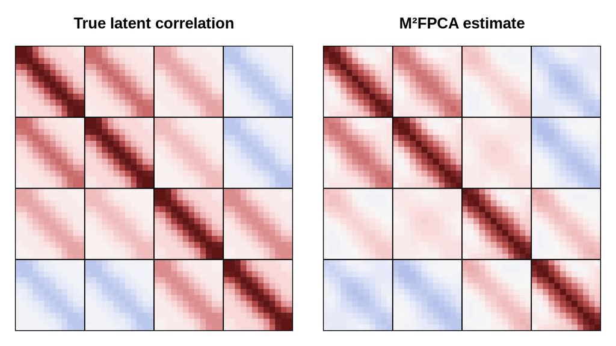

```r
R_hat  <- cov2cor(cov.from.mpfpca.dir(fit))
# analytic truth: Rbase (x) cov2cor(K),  K = sum_l lambda_l phi_l phi_l'
phi <- st$phi; lambda <- st$lambda; Rbase <- st$Rbase
K_true <- Reduce("+", lapply(1:ncol(phi), function(l) lambda[l] * outer(phi[,l], phi[,l])))
R_true <- kronecker(Rbase, cov2cor(K_true))

heat <- function(M, main) {
  image(1:nrow(M), 1:ncol(M), M[, ncol(M):1], col = hcl.colors(64, "Blue-Red 3"),
        zlim = c(-1, 1), axes = FALSE, xlab = "", ylab = "", main = main); box()
  ab <- (1:(p - 1)) * m + 0.5; abline(v = ab, h = nrow(M) - ab + 1, lwd = 1.4)
}
op <- par(mfrow = c(1, 2), mar = c(1, 1, 3, 1))
heat(R_true, "True latent correlation"); heat(R_hat, "M²FPCA estimate")
```

```r
par(op)

rel_err <- norm(R_hat - R_true, "F") / norm(R_true, "F")
vcor    <- cor(as.numeric(R_hat), as.numeric(R_true))
cat(sprintf("relative Frobenius error: %.3f  |  cor(vec(true), vec(est)): %.3f\n",
            rel_err, vcor))
```

```
## relative Frobenius error: 0.226  |  cor(vec(true), vec(est)): 0.978
```

Each `m × m` block is one domain pair; the estimate closely matches the truth both on the marginal (diagonal) blocks and the cross blocks.

# 7 Step 4 — Subject-level scores (digital biomarkers)

`mpfpca_scores()` predicts each domain’s latent trajectory and projects it onto the shared eigenfunctions, giving per-subject component scores. These are the candidate *digital biomarkers*.

```r
sc_file <- file.path(cache, "scores.rds")
if (file.exists(sc_file)) {
  sc <- readRDS(sc_file)
} else {
  sc <- mpfpca_scores(dat_list, type, fit, argvals, npc = 4,
                      ridge = 0.05, impute.missing = TRUE)
  saveRDS(sc, sc_file)
}

# mpfpca_scores() labels the p domains V1..Vp; relabel with domain abbreviations
dom_abbr <- c("Mood", "Anx", "Energy", "TLAC")
relabel <- function(x) { for (k in seq_along(dom_abbr))
  colnames(x) <- sub(paste0("^V", k, "_"), paste0(dom_abbr[k], "_"), colnames(x)); x }
sc$scores      <- lapply(sc$scores, relabel)
sc$scores_wide <- relabel(sc$scores_wide)
dim(sc$scores_wide)          # n x (npc * p)
```

```
## [1] 160  16
```

## 7.1 Cross-domain score correlation recovers the coupling

```r
round(cor(sc$scores[[1]], use = "pairwise.complete.obs"), 2)
```

```
##            Mood_PC1 Anx_PC1 Energy_PC1 TLAC_PC1
## Mood_PC1       1.00    0.52       0.17    -0.36
## Anx_PC1        0.52    1.00       0.19    -0.34
## Energy_PC1     0.17    0.19       1.00     0.29
## TLAC_PC1      -0.36   -0.34       0.29     1.00
```

The component-1 scores reproduce the generative coupling: mood–anxiety positive, activity negatively related to the low-mood domains.

## 7.2 Biomarkers separate diagnostic groups

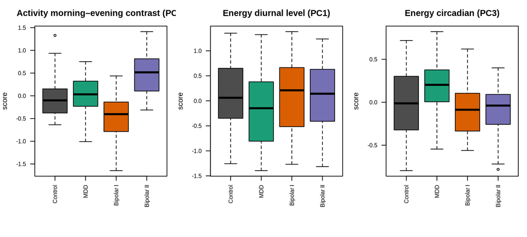

```r
sw <- as.data.frame(sc$scores_wide); sw$group <- group
show <- c("TLAC_PC2", "Energy_PC1", "Energy_PC3")
labs <- c("Activity morning–evening contrast (PC2)",
          "Energy diurnal level (PC1)", "Energy circadian (PC3)")
op <- par(mfrow = c(1, 3), mar = c(7, 4, 3, 1))
for (k in seq_along(show)) {
  boxplot(sw[[show[k]]] ~ sw$group, col = gcol[levels(group)], las = 2,
          xlab = "", ylab = "score", main = labs[k], cex.axis = .8)
}
```

```r
par(op)
```

As in the paper, the **activity morning–evening contrast** separates Bipolar I from Bipolar II, and **energy** components track MDD.

# 8 Step 5 — Multivariate prediction of diagnostic group

Finally we use the component scores as features in a multinomial classifier (the analogue of the paper’s multinomial-LASSO digital-phenotyping step), with a stratified train/test split.

```r
suppressMessages(library(nnet))
feats <- as.data.frame(sc$scores_wide); feats$group <- group
ok <- complete.cases(sc$scores_wide); feats <- feats[ok, ]
set.seed(7)
tr <- unlist(lapply(split(seq_len(nrow(feats)), feats$group),
                    function(idx) sample(idx, round(0.7 * length(idx)))))
train <- feats[tr, ]; test <- feats[-tr, ]

fit_mn <- multinom(group ~ ., data = train, trace = FALSE, maxit = 500)
pred   <- predict(fit_mn, newdata = test)
acc    <- mean(pred == test$group)
base   <- max(table(train$group)) / nrow(train)
cat(sprintf("test accuracy: %.2f   (majority baseline %.2f, chance %.2f)\n",
            acc, base, 1 / length(groups)))
```

```
## test accuracy: 0.60   (majority baseline 0.25, chance 0.25)
```

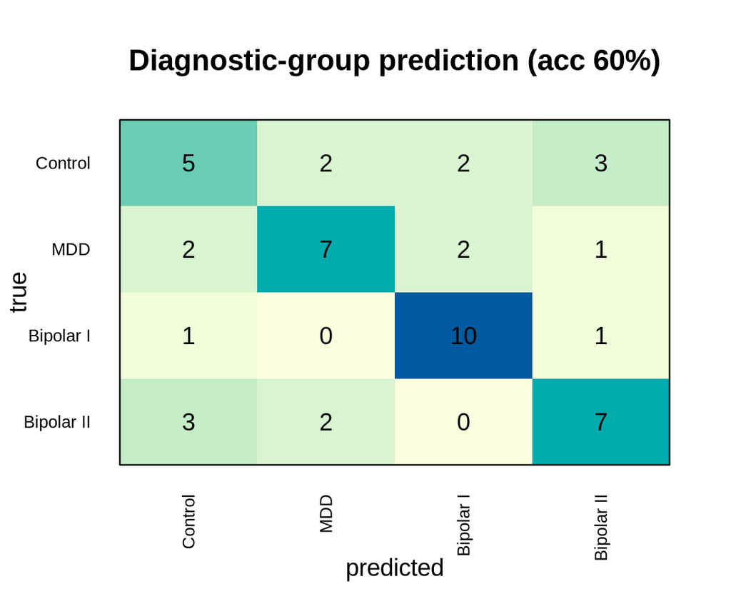

```r
cm <- table(true = test$group, predicted = pred)
image(1:ncol(cm), 1:nrow(cm), t(cm / rowSums(cm))[, nrow(cm):1],
      col = hcl.colors(32, "YlGnBu", rev = TRUE), zlim = c(0, 1), axes = FALSE,
      xlab = "predicted", ylab = "true",
      main = sprintf("Diagnostic-group prediction (acc %.0f%%)", 100 * acc))
axis(1, 1:ncol(cm), colnames(cm), las = 2, cex.axis = .7, tick = FALSE)
axis(2, 1:nrow(cm), rev(rownames(cm)), las = 1, cex.axis = .7, tick = FALSE)
for (a in 1:ncol(cm)) for (b in 1:nrow(cm))
  text(a, nrow(cm) - b + 1, cm[b, a], cex = 1)
box()
```

```r
cm
```

```
##             predicted
## true         Control MDD Bipolar I Bipolar II
##   Control          5   2         2          3
##   MDD              2   7         2          1
##   Bipolar I        1   0        10          1
##   Bipolar II       3   2         0          7
```

# 9 Summary

Starting from sparse, asynchronous, mixed-type mHealth data, M²FPCA:

- estimated the full joint latent correlation with high fidelity (`cor(vec) ≈ 0.98`),
- recovered three interpretable shared diurnal components,
- produced subject-level scores that reflect the true cross-domain coupling, and
- yielded digital biomarkers that stratify diagnostic groups.

These numbers are illustrative: the sample is small and the generative model is known, so recovery is easier than in the real study. The point is to show the **M²FPCA workflow end-to-end on data with the same structure** as the paper.

> **Reproducibility.** The two slow steps (the fit and the latent prediction) are cached under `analysis_cache/`. Delete that folder and re-knit to recompute everything from scratch.

**Citation.** Dey, D., Ghosal, R., Merikangas, K., & Zipunnikov, V. (2026). *Multivariate Functional Principal Component Analysis for Mixed-Type mHealth Data: An Application to Mood Disorders.* arXiv:2603.11385.